#Project #1 for Coursera Reproducible Research Class

##There are several parts to this assignment. The first part is:

1 Load the data

```r
fit_data <- read.csv("activity.csv")
```

2 Process/transform the data (if necessary) into a format suitable for your analysis

```r
fit_data <- subset(fit_data,!is.na(fit_data[,1]))
```

##What is mean total number of steps taken per day?

1 (Calculate the total number of steps taken per day

```r
day_sum <- 0
daily_sum <- 0
for (a in 1:53) {
        for (b in 1:288) {
                day_sum <- day_sum + fit_data[a*b,1]
                }
        daily_sum[a] <- day_sum
        day_sum <- 0
}
```

2 If you do not understand the difference between a histogram and a barplot, research the difference between them. Make a histogram of the total number of steps taken each day

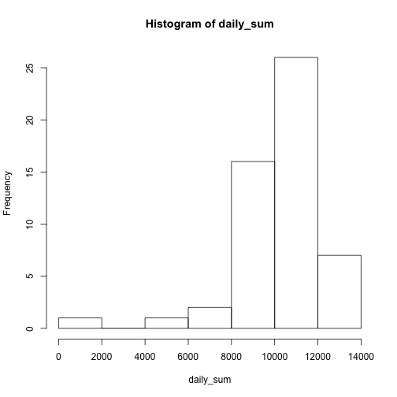

```r
hist(daily_sum)
```

3 Calculate and report the mean and median of the total number of steps taken per day

```r
print(mean(daily_sum))
```

```
## [1] 10306.6
```

```r
print(median(daily_sum))
```

```
## [1] 10671
```

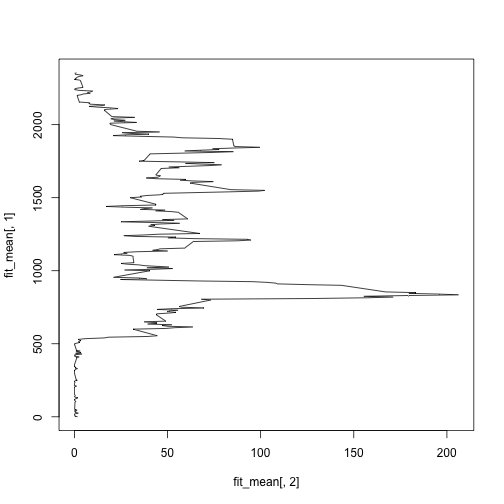

```r
fit_mean <- aggregate(fit_data[,1], list(fit_data[,3]), mean)
plot(fit_mean[,2],fit_mean[,1],type = "l")
```

2 Which 5-minute interval, on average across all the days in the dataset, contains the maximum number of steps?

```r
print(fit_mean[match(max(fit_mean[,2]),fit_mean[,2]),1])
```

```
## [1] 835
```

##Inputing missing values

1 Calculate and report the total number of missing values in the dataset (i.e. the total number of rows with NAs)

```r
print(nrow(subset(fit_data,is.na(fit_data[,1]))))
```

```
## [1] 0
```

2 Devise a strategy for filling in all of the missing values in the dataset. The strategy does not need to be sophisticated. For example, you could use the mean/median for that day, or the mean for that 5-minute interval, etc.

For each time interval, 37 is close to the average step amount overall. My strategy is to replace all NA values with the number 37, so that the average doesn't get affected too strongly.

3 Create a new dataset that is equal to the original dataset but with the missing data filled in.

```r
fit_data2 <- fit_data
fit_data2[is.na(fit_data2)] <- 37
```

4 Make a histogram of the total number of steps taken each day and Calculate and report the mean and median total number of steps taken per day.

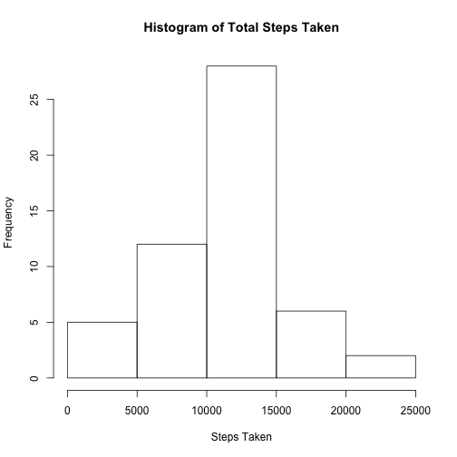

```r
fit_total <- aggregate(fit_data2[,1], list(fit_data2[,2]), sum)
hist(fit_total[,2], main = "Histogram of Total Steps Taken", xlab = "Steps Taken")
```

```r
print(mean(fit_total[,2]))
```

```
## [1] 10766.19
```

```r
print(median(fit_total[,2]))
```

```
## [1] 10765
```

##Are there differences in activity patterns between weekdays and weekends? 1 Create a new factor variable in the dataset with two levels – “weekday” and “weekend” indicating whether a given date is a weekday or weekend day.

```r
fit_data2$Day <- weekdays(as.Date(fit_data2[,2]))
fit_data2$Day <- sub("Monday", "weekday", fit_data2$Day)
fit_data2$Day <- sub("Tuesday", "weekday", fit_data2$Day)
fit_data2$Day <- sub("Wednesday", "weekday", fit_data2$Day)
fit_data2$Day <- sub("Thursday", "weekday", fit_data2$Day)
fit_data2$Day <- sub("Friday", "weekday", fit_data2$Day)
fit_data2$Day <- sub("Saturday", "weekend", fit_data2$Day)
fit_data2$Day <- sub("Sunday", "weekend", fit_data2$Day)
```

1. Make a panel plot containing a time series plot (i.e. type = “l”) of the 5-minute interval (x-axis) and the average number of steps taken, averaged across all weekday days or weekend days (y-axis). Set up 2 panels, and plot to the screen.

```r
fit_mean2 <- aggregate(fit_data2, list(fit_data2[,4],fit_data2[,3]), data = fit_data2$steps, mean)
```

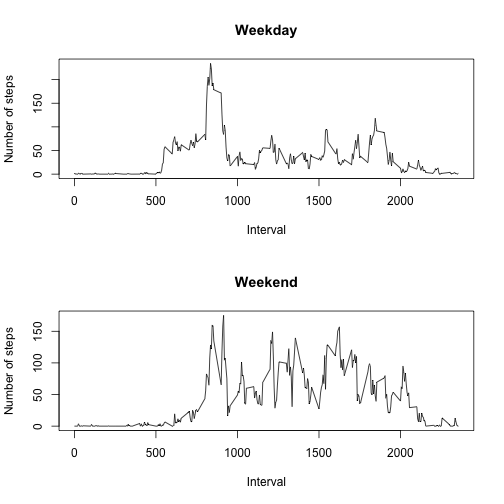

```r
fit_plot1 <- subset(fit_mean2, fit_mean2[,1] == "weekday")
fit_plot2 <- subset(fit_mean2, fit_mean2[,1] == "weekend")
par(mfcol = c(2, 1))
plot(fit_plot1[,2],fit_plot1[,3], xlab = "Interval", ylab = "Number of steps", main = "Weekday", type = "l")
plot(fit_plot2[,2],fit_plot2[,3], xlab = "Interval", ylab = "Number of steps", main = "Weekend", type = "l")
```